# weather_to_CB

## Weather EDA

### DS 5110: Big Data Systems

### By: TeamBike

**Create the SparkSession instance with appName 'weather'.**

```python
# need to import SparkSession
# make .appName 'weather'

from pyspark.sql import SparkSession

spark = SparkSession.builder \
        .appName("weather") \
        .getOrCreate()
```

```python
%matplotlib inline
```

**Read in the dataset**

```python
# note that read.json can read a zipped JSON directly
df = spark.read.parquet("/project/ds5559/Summer2021_TeamBike/weatherRainSnowClouds.parquet");
print(type(df)) # I want to see what type of object this created to make sure it's a DF
```

```
<class 'pyspark.sql.dataframe.DataFrame'>
```

**Data has been read in and set to variable *df* as a data frame. Record count is:**

```python
print('There are %1d records in the data.' % (df.count())) # show the number of records:
```

```
There are 79287 records in the data.
```

**Print the schema**

**Can print the schema using *.printSchema()*. Schema is:**

```python
df.printSchema()
```

```
root
 |-- dt: long (nullable = true)
 |-- dt_iso: string (nullable = true)
 |-- temp: double (nullable = true)
 |-- feels_like: double (nullable = true)
 |-- temp_min: double (nullable = true)
 |-- temp_max: double (nullable = true)
 |-- pressure: long (nullable = true)
 |-- humidity: long (nullable = true)
 |-- wind_speed: double (nullable = true)
 |-- rain_1h: double (nullable = true)
 |-- rain_3h: double (nullable = true)
 |-- snow_1h: double (nullable = true)
 |-- snow_3h: double (nullable = true)
 |-- clouds_all: long (nullable = true)
 |-- weather_id: long (nullable = true)
 |-- weather_main: string (nullable = true)
```

**Showing the first 5 records using *show()*:**

```python
df.show(5) # show top-5 rows using .show()
```

```
+----------+--------------------+------+----------+--------+--------+--------+--------+----------+-------+-------+-------+-------+----------+----------+------------+
|        dt|              dt_iso|  temp|feels_like|temp_min|temp_max|pressure|humidity|wind_speed|rain_1h|rain_3h|snow_1h|snow_3h|clouds_all|weather_id|weather_main|
+----------+--------------------+------+----------+--------+--------+--------+--------+----------+-------+-------+-------+-------+----------+----------+------------+
|1457467200|2016-03-08 20:00:...|288.17|    283.38| 282.685|  290.35|    1020|      37|       4.1|    NaN|    NaN|    NaN|    NaN|         1|       800|       Clear|
|1457470800|2016-03-08 21:00:...|286.82|    283.72| 282.205|  289.25|    1020|      46|       2.1|    NaN|    NaN|    NaN|    NaN|         1|       800|       Clear|
|1457474400|2016-03-08 22:00:...|285.94|    283.32| 281.925|  287.55|    1020|      50|       1.5|    NaN|    NaN|    NaN|    NaN|         1|       721|        Haze|
|1457478000|2016-03-08 23:00:...|284.89|    282.38| 281.851|  286.45|    1020|      56|       1.5|    NaN|    NaN|    NaN|    NaN|         1|       721|        Haze|
|1457481600|2016-03-09 00:00:...|283.86|    280.99| 281.617|  284.85|    1021|      60|      2.02|    NaN|    NaN|    NaN|    NaN|         1|       800|       Clear|
+----------+--------------------+------+----------+--------+--------+--------+--------+----------+-------+-------+-------+-------+----------+----------+------------+
only showing top 5 rows
```

**Notice NaN values in some fields. Replace with 0 here since they represent no precipitation.**

```python
df = df.na.fill(value=0,subset=['rain_1h', 'rain_3h', 'snow_1h', 'snow_3h'])
```

### Feature Engineering

```python
from pyspark.sql.functions import round, col, dayofweek, split, create_map, lit, udf
from itertools import chain
from pyspark.sql.types import StringType, IntegerType
```

**Clean up the date field.**

```python
df = df.withColumn('date', split(df['dt_iso'], ' ').getItem(0)) \
       .withColumn('time', split(df['dt_iso'], ' ').getItem(1)) \
#df.show(truncate=False)
```

```python
df.show(truncate=False)
```

```
+----------+-----------------------------+------+----------+--------+--------+--------+--------+----------+-------+-------+-------+-------+----------+----------+------------+----------+--------+
|dt        |dt_iso                       |temp  |feels_like|temp_min|temp_max|pressure|humidity|wind_speed|rain_1h|rain_3h|snow_1h|snow_3h|clouds_all|weather_id|weather_main|date      |time    |
+----------+-----------------------------+------+----------+--------+--------+--------+--------+----------+-------+-------+-------+-------+----------+----------+------------+----------+--------+
|1457467200|2016-03-08 20:00:00 +0000 UTC|288.17|283.38    |282.685 |290.35  |1020    |37      |4.1       |0.0    |0.0    |0.0    |0.0    |1         |800       |Clear       |2016-03-08|20:00:00|
|1457470800|2016-03-08 21:00:00 +0000 UTC|286.82|283.72    |282.205 |289.25  |1020    |46      |2.1       |0.0    |0.0    |0.0    |0.0    |1         |800       |Clear       |2016-03-08|21:00:00|
|1457474400|2016-03-08 22:00:00 +0000 UTC|285.94|283.32    |281.925 |287.55  |1020    |50      |1.5       |0.0    |0.0    |0.0    |0.0    |1         |721       |Haze        |2016-03-08|22:00:00|
|1457478000|2016-03-08 23:00:00 +0000 UTC|284.89|282.38    |281.851 |286.45  |1020    |56      |1.5       |0.0    |0.0    |0.0    |0.0    |1         |721       |Haze        |2016-03-08|23:00:00|
|1457481600|2016-03-09 00:00:00 +0000 UTC|283.86|280.99    |281.617 |284.85  |1021    |60      |2.02      |0.0    |0.0    |0.0    |0.0    |1         |800       |Clear       |2016-03-09|00:00:00|
|1457485200|2016-03-09 01:00:00 +0000 UTC|283.38|280.8     |281.654 |284.25  |1021    |60      |1.5       |0.0    |0.0    |0.0    |0.0    |1         |800       |Clear       |2016-03-09|01:00:00|
|1457488800|2016-03-09 02:00:00 +0000 UTC|282.86|279.97    |281.649 |283.75  |1021    |65      |2.1       |0.0    |0.0    |0.0    |0.0    |1         |800       |Clear       |2016-03-09|02:00:00|
|1457492400|2016-03-09 03:00:00 +0000 UTC|282.4 |279.85    |281.14  |283.15  |1021    |65      |1.5       |0.0    |0.0    |0.0    |0.0    |1         |800       |Clear       |2016-03-09|03:00:00|
|1457496000|2016-03-09 04:00:00 +0000 UTC|281.91|279.39    |280.923 |282.55  |1021    |68      |1.5       |0.0    |0.0    |0.0    |0.0    |1         |800       |Clear       |2016-03-09|04:00:00|
|1457499600|2016-03-09 05:00:00 +0000 UTC|281.24|278.37    |280.265 |282.05  |1021    |73      |2.1       |0.0    |0.0    |0.0    |0.0    |1         |721       |Haze        |2016-03-09|05:00:00|
|1457503200|2016-03-09 06:00:00 +0000 UTC|281.19|278.83    |280.507 |281.45  |1020    |76      |1.5       |0.0    |0.0    |0.0    |0.0    |1         |721       |Haze        |2016-03-09|06:00:00|
|1457506800|2016-03-09 07:00:00 +0000 UTC|280.46|277.97    |279.25  |281.45  |1021    |76      |1.5       |0.0    |0.0    |0.0    |0.0    |1         |721       |Haze        |2016-03-09|07:00:00|
|1457510400|2016-03-09 08:00:00 +0000 UTC|280.17|277.55    |279.25  |280.95  |1020    |79      |1.76      |0.0    |0.0    |0.0    |0.0    |1         |721       |Haze        |2016-03-09|08:00:00|
|1457514000|2016-03-09 09:00:00 +0000 UTC|280.03|277.03    |279.25  |280.95  |1020    |76      |2.12      |0.0    |0.0    |0.0    |0.0    |1         |721       |Haze        |2016-03-09|09:00:00|
|1457517600|2016-03-09 10:00:00 +0000 UTC|279.46|276.9     |278.703 |280.35  |1021    |79      |1.5       |0.0    |0.0    |0.0    |0.0    |1         |721       |Haze        |2016-03-09|10:00:00|
|1457521200|2016-03-09 11:00:00 +0000 UTC|279.22|276.25    |278.15  |280.35  |1021    |79      |2.02      |0.0    |0.0    |0.0    |0.0    |1         |721       |Haze        |2016-03-09|11:00:00|
|1457524800|2016-03-09 12:00:00 +0000 UTC|279.66|277.13    |278.643 |280.462 |1021    |79      |1.5       |0.0    |0.0    |0.0    |0.0    |1         |721       |Haze        |2016-03-09|12:00:00|
|1457528400|2016-03-09 13:00:00 +0000 UTC|281.39|279.07    |279.509 |282.55  |1021    |70      |1.19      |0.0    |0.0    |0.0    |0.0    |1         |721       |Haze        |2016-03-09|13:00:00|
|1457532000|2016-03-09 14:00:00 +0000 UTC|284.2 |281.54    |281.723 |285.95  |1021    |59      |1.74      |0.0    |0.0    |0.0    |0.0    |1         |721       |Haze        |2016-03-09|14:00:00|
|1457535600|2016-03-09 15:00:00 +0000 UTC|286.78|283.99    |284.241 |288.15  |1021    |47      |1.72      |0.0    |0.0    |0.0    |0.0    |1         |721       |Haze        |2016-03-09|15:00:00|
+----------+-----------------------------+------+----------+--------+--------+--------+--------+----------+-------+-------+-------+-------+----------+----------+------------+----------+--------+
only showing top 20 rows
```

```python
# no longer need the full date field
df = df.drop('dt_iso', 'dt_iso', 'dt')\
.withColumn('temp_min',round('temp_min',3))\
.withColumn('temp_max',round('temp_min',3))\
```

```python
df.show(truncate=False)
```

```
+------+----------+--------+--------+--------+--------+----------+-------+-------+-------+-------+----------+----------+------------+----------+--------+
|temp  |feels_like|temp_min|temp_max|pressure|humidity|wind_speed|rain_1h|rain_3h|snow_1h|snow_3h|clouds_all|weather_id|weather_main|date      |time    |
+------+----------+--------+--------+--------+--------+----------+-------+-------+-------+-------+----------+----------+------------+----------+--------+
|288.17|283.38    |282.685 |282.685 |1020    |37      |4.1       |0.0    |0.0    |0.0    |0.0    |1         |800       |Clear       |2016-03-08|20:00:00|
|286.82|283.72    |282.205 |282.205 |1020    |46      |2.1       |0.0    |0.0    |0.0    |0.0    |1         |800       |Clear       |2016-03-08|21:00:00|
|285.94|283.32    |281.925 |281.925 |1020    |50      |1.5       |0.0    |0.0    |0.0    |0.0    |1         |721       |Haze        |2016-03-08|22:00:00|
|284.89|282.38    |281.851 |281.851 |1020    |56      |1.5       |0.0    |0.0    |0.0    |0.0    |1         |721       |Haze        |2016-03-08|23:00:00|
|283.86|280.99    |281.617 |281.617 |1021    |60      |2.02      |0.0    |0.0    |0.0    |0.0    |1         |800       |Clear       |2016-03-09|00:00:00|
|283.38|280.8     |281.654 |281.654 |1021    |60      |1.5       |0.0    |0.0    |0.0    |0.0    |1         |800       |Clear       |2016-03-09|01:00:00|
|282.86|279.97    |281.649 |281.649 |1021    |65      |2.1       |0.0    |0.0    |0.0    |0.0    |1         |800       |Clear       |2016-03-09|02:00:00|
|282.4 |279.85    |281.14  |281.14  |1021    |65      |1.5       |0.0    |0.0    |0.0    |0.0    |1         |800       |Clear       |2016-03-09|03:00:00|
|281.91|279.39    |280.923 |280.923 |1021    |68      |1.5       |0.0    |0.0    |0.0    |0.0    |1         |800       |Clear       |2016-03-09|04:00:00|
|281.24|278.37    |280.265 |280.265 |1021    |73      |2.1       |0.0    |0.0    |0.0    |0.0    |1         |721       |Haze        |2016-03-09|05:00:00|
|281.19|278.83    |280.507 |280.507 |1020    |76      |1.5       |0.0    |0.0    |0.0    |0.0    |1         |721       |Haze        |2016-03-09|06:00:00|
|280.46|277.97    |279.25  |279.25  |1021    |76      |1.5       |0.0    |0.0    |0.0    |0.0    |1         |721       |Haze        |2016-03-09|07:00:00|
|280.17|277.55    |279.25  |279.25  |1020    |79      |1.76      |0.0    |0.0    |0.0    |0.0    |1         |721       |Haze        |2016-03-09|08:00:00|
|280.03|277.03    |279.25  |279.25  |1020    |76      |2.12      |0.0    |0.0    |0.0    |0.0    |1         |721       |Haze        |2016-03-09|09:00:00|
|279.46|276.9     |278.703 |278.703 |1021    |79      |1.5       |0.0    |0.0    |0.0    |0.0    |1         |721       |Haze        |2016-03-09|10:00:00|
|279.22|276.25    |278.15  |278.15  |1021    |79      |2.02      |0.0    |0.0    |0.0    |0.0    |1         |721       |Haze        |2016-03-09|11:00:00|
|279.66|277.13    |278.643 |278.643 |1021    |79      |1.5       |0.0    |0.0    |0.0    |0.0    |1         |721       |Haze        |2016-03-09|12:00:00|
|281.39|279.07    |279.509 |279.509 |1021    |70      |1.19      |0.0    |0.0    |0.0    |0.0    |1         |721       |Haze        |2016-03-09|13:00:00|
|284.2 |281.54    |281.723 |281.723 |1021    |59      |1.74      |0.0    |0.0    |0.0    |0.0    |1         |721       |Haze        |2016-03-09|14:00:00|
|286.78|283.99    |284.241 |284.241 |1021    |47      |1.72      |0.0    |0.0    |0.0    |0.0    |1         |721       |Haze        |2016-03-09|15:00:00|
+------+----------+--------+--------+--------+--------+----------+-------+-------+-------+-------+----------+----------+------------+----------+--------+
only showing top 20 rows
```

#### Create Day and Month Dictionaries to map variables

```python
days = ['Sunday', 'Monday', 'Tuesday', 'Wednesday', 'Thursday', 'Friday', 'Saturday'];
dow = {i + 1:days[i] for i in range(7)};
mos = ['Jan', 'Feb', 'Mar', 'Apr', 'May', 'Jun', 'Jul', 'Aug', 'Sep', 'Oct', 'Nov', 'Dec'];
mos_d = {i + 1:mos[i] for i in range(12)};
```

```python
dow
```

```
{1: 'Sunday',
 2: 'Monday',
 3: 'Tuesday',
 4: 'Wednesday',
 5: 'Thursday',
 6: 'Friday',
 7: 'Saturday'}
```

```python
mos_d
```

```
{1: 'Jan',
 2: 'Feb',
 3: 'Mar',
 4: 'Apr',
 5: 'May',
 6: 'Jun',
 7: 'Jul',
 8: 'Aug',
 9: 'Sep',
 10: 'Oct',
 11: 'Nov',
 12: 'Dec'}
```

```python
# return the day of the week for each date
df = df.withColumn('dow', dayofweek('date'));
df.show(truncate=False)
```

```
+------+----------+--------+--------+--------+--------+----------+-------+-------+-------+-------+----------+----------+------------+----------+--------+---+
|temp  |feels_like|temp_min|temp_max|pressure|humidity|wind_speed|rain_1h|rain_3h|snow_1h|snow_3h|clouds_all|weather_id|weather_main|date      |time    |dow|
+------+----------+--------+--------+--------+--------+----------+-------+-------+-------+-------+----------+----------+------------+----------+--------+---+
|288.17|283.38    |282.685 |282.685 |1020    |37      |4.1       |0.0    |0.0    |0.0    |0.0    |1         |800       |Clear       |2016-03-08|20:00:00|3  |
|286.82|283.72    |282.205 |282.205 |1020    |46      |2.1       |0.0    |0.0    |0.0    |0.0    |1         |800       |Clear       |2016-03-08|21:00:00|3  |
|285.94|283.32    |281.925 |281.925 |1020    |50      |1.5       |0.0    |0.0    |0.0    |0.0    |1         |721       |Haze        |2016-03-08|22:00:00|3  |
|284.89|282.38    |281.851 |281.851 |1020    |56      |1.5       |0.0    |0.0    |0.0    |0.0    |1         |721       |Haze        |2016-03-08|23:00:00|3  |
|283.86|280.99    |281.617 |281.617 |1021    |60      |2.02      |0.0    |0.0    |0.0    |0.0    |1         |800       |Clear       |2016-03-09|00:00:00|4  |
|283.38|280.8     |281.654 |281.654 |1021    |60      |1.5       |0.0    |0.0    |0.0    |0.0    |1         |800       |Clear       |2016-03-09|01:00:00|4  |
|282.86|279.97    |281.649 |281.649 |1021    |65      |2.1       |0.0    |0.0    |0.0    |0.0    |1         |800       |Clear       |2016-03-09|02:00:00|4  |
|282.4 |279.85    |281.14  |281.14  |1021    |65      |1.5       |0.0    |0.0    |0.0    |0.0    |1         |800       |Clear       |2016-03-09|03:00:00|4  |
|281.91|279.39    |280.923 |280.923 |1021    |68      |1.5       |0.0    |0.0    |0.0    |0.0    |1         |800       |Clear       |2016-03-09|04:00:00|4  |
|281.24|278.37    |280.265 |280.265 |1021    |73      |2.1       |0.0    |0.0    |0.0    |0.0    |1         |721       |Haze        |2016-03-09|05:00:00|4  |
|281.19|278.83    |280.507 |280.507 |1020    |76      |1.5       |0.0    |0.0    |0.0    |0.0    |1         |721       |Haze        |2016-03-09|06:00:00|4  |
|280.46|277.97    |279.25  |279.25  |1021    |76      |1.5       |0.0    |0.0    |0.0    |0.0    |1         |721       |Haze        |2016-03-09|07:00:00|4  |
|280.17|277.55    |279.25  |279.25  |1020    |79      |1.76      |0.0    |0.0    |0.0    |0.0    |1         |721       |Haze        |2016-03-09|08:00:00|4  |
|280.03|277.03    |279.25  |279.25  |1020    |76      |2.12      |0.0    |0.0    |0.0    |0.0    |1         |721       |Haze        |2016-03-09|09:00:00|4  |
|279.46|276.9     |278.703 |278.703 |1021    |79      |1.5       |0.0    |0.0    |0.0    |0.0    |1         |721       |Haze        |2016-03-09|10:00:00|4  |
|279.22|276.25    |278.15  |278.15  |1021    |79      |2.02      |0.0    |0.0    |0.0    |0.0    |1         |721       |Haze        |2016-03-09|11:00:00|4  |
|279.66|277.13    |278.643 |278.643 |1021    |79      |1.5       |0.0    |0.0    |0.0    |0.0    |1         |721       |Haze        |2016-03-09|12:00:00|4  |
|281.39|279.07    |279.509 |279.509 |1021    |70      |1.19      |0.0    |0.0    |0.0    |0.0    |1         |721       |Haze        |2016-03-09|13:00:00|4  |
|284.2 |281.54    |281.723 |281.723 |1021    |59      |1.74      |0.0    |0.0    |0.0    |0.0    |1         |721       |Haze        |2016-03-09|14:00:00|4  |
|286.78|283.99    |284.241 |284.241 |1021    |47      |1.72      |0.0    |0.0    |0.0    |0.0    |1         |721       |Haze        |2016-03-09|15:00:00|4  |
+------+----------+--------+--------+--------+--------+----------+-------+-------+-------+-------+----------+----------+------------+----------+--------+---+
only showing top 20 rows
```

**Create mapping function:**

```python
def translate(mapping):
    def translate_(col):
        return mapping.get(col)
    return udf(translate_, StringType())

df = df.withColumn('day', translate(dow)('dow')) # map from dow to actual day name (Monday, Tuesday, etc.)
```

```python
df.show()
```

```
+------+----------+--------+--------+--------+--------+----------+-------+-------+-------+-------+----------+----------+------------+----------+--------+---+---------+
|  temp|feels_like|temp_min|temp_max|pressure|humidity|wind_speed|rain_1h|rain_3h|snow_1h|snow_3h|clouds_all|weather_id|weather_main|      date|    time|dow|      day|
+------+----------+--------+--------+--------+--------+----------+-------+-------+-------+-------+----------+----------+------------+----------+--------+---+---------+
|288.17|    283.38| 282.685| 282.685|    1020|      37|       4.1|    0.0|    0.0|    0.0|    0.0|         1|       800|       Clear|2016-03-08|20:00:00|  3|  Tuesday|
|286.82|    283.72| 282.205| 282.205|    1020|      46|       2.1|    0.0|    0.0|    0.0|    0.0|         1|       800|       Clear|2016-03-08|21:00:00|  3|  Tuesday|
|285.94|    283.32| 281.925| 281.925|    1020|      50|       1.5|    0.0|    0.0|    0.0|    0.0|         1|       721|        Haze|2016-03-08|22:00:00|  3|  Tuesday|
|284.89|    282.38| 281.851| 281.851|    1020|      56|       1.5|    0.0|    0.0|    0.0|    0.0|         1|       721|        Haze|2016-03-08|23:00:00|  3|  Tuesday|
|283.86|    280.99| 281.617| 281.617|    1021|      60|      2.02|    0.0|    0.0|    0.0|    0.0|         1|       800|       Clear|2016-03-09|00:00:00|  4|Wednesday|
|283.38|     280.8| 281.654| 281.654|    1021|      60|       1.5|    0.0|    0.0|    0.0|    0.0|         1|       800|       Clear|2016-03-09|01:00:00|  4|Wednesday|
|282.86|    279.97| 281.649| 281.649|    1021|      65|       2.1|    0.0|    0.0|    0.0|    0.0|         1|       800|       Clear|2016-03-09|02:00:00|  4|Wednesday|
| 282.4|    279.85|  281.14|  281.14|    1021|      65|       1.5|    0.0|    0.0|    0.0|    0.0|         1|       800|       Clear|2016-03-09|03:00:00|  4|Wednesday|
|281.91|    279.39| 280.923| 280.923|    1021|      68|       1.5|    0.0|    0.0|    0.0|    0.0|         1|       800|       Clear|2016-03-09|04:00:00|  4|Wednesday|
|281.24|    278.37| 280.265| 280.265|    1021|      73|       2.1|    0.0|    0.0|    0.0|    0.0|         1|       721|        Haze|2016-03-09|05:00:00|  4|Wednesday|
|281.19|    278.83| 280.507| 280.507|    1020|      76|       1.5|    0.0|    0.0|    0.0|    0.0|         1|       721|        Haze|2016-03-09|06:00:00|  4|Wednesday|
|280.46|    277.97|  279.25|  279.25|    1021|      76|       1.5|    0.0|    0.0|    0.0|    0.0|         1|       721|        Haze|2016-03-09|07:00:00|  4|Wednesday|
|280.17|    277.55|  279.25|  279.25|    1020|      79|      1.76|    0.0|    0.0|    0.0|    0.0|         1|       721|        Haze|2016-03-09|08:00:00|  4|Wednesday|
|280.03|    277.03|  279.25|  279.25|    1020|      76|      2.12|    0.0|    0.0|    0.0|    0.0|         1|       721|        Haze|2016-03-09|09:00:00|  4|Wednesday|
|279.46|     276.9| 278.703| 278.703|    1021|      79|       1.5|    0.0|    0.0|    0.0|    0.0|         1|       721|        Haze|2016-03-09|10:00:00|  4|Wednesday|
|279.22|    276.25|  278.15|  278.15|    1021|      79|      2.02|    0.0|    0.0|    0.0|    0.0|         1|       721|        Haze|2016-03-09|11:00:00|  4|Wednesday|
|279.66|    277.13| 278.643| 278.643|    1021|      79|       1.5|    0.0|    0.0|    0.0|    0.0|         1|       721|        Haze|2016-03-09|12:00:00|  4|Wednesday|
|281.39|    279.07| 279.509| 279.509|    1021|      70|      1.19|    0.0|    0.0|    0.0|    0.0|         1|       721|        Haze|2016-03-09|13:00:00|  4|Wednesday|
| 284.2|    281.54| 281.723| 281.723|    1021|      59|      1.74|    0.0|    0.0|    0.0|    0.0|         1|       721|        Haze|2016-03-09|14:00:00|  4|Wednesday|
|286.78|    283.99| 284.241| 284.241|    1021|      47|      1.72|    0.0|    0.0|    0.0|    0.0|         1|       721|        Haze|2016-03-09|15:00:00|  4|Wednesday|
+------+----------+--------+--------+--------+--------+----------+-------+-------+-------+-------+----------+----------+------------+----------+--------+---+---------+
only showing top 20 rows
```

**Isolate hour, month, etc.**

```python
df = df.withColumn('month', split(df['date'], '-').getItem(1))\
.withColumn('hour', split(df['time'], ':').getItem(0)) \
```

**Map from month number to month name:**

```python
df = df.withColumn('month', df['month'].cast(IntegerType()))\
.withColumn('month', translate(mos_d)('month'))\
.withColumn('hour', df['hour'].cast(IntegerType()))
```

```python
df.show()
```

```
+------+----------+--------+--------+--------+--------+----------+-------+-------+-------+-------+----------+----------+------------+----------+--------+---+---------+-----+----+
|  temp|feels_like|temp_min|temp_max|pressure|humidity|wind_speed|rain_1h|rain_3h|snow_1h|snow_3h|clouds_all|weather_id|weather_main|      date|    time|dow|      day|month|hour|
+------+----------+--------+--------+--------+--------+----------+-------+-------+-------+-------+----------+----------+------------+----------+--------+---+---------+-----+----+
|288.17|    283.38| 282.685| 282.685|    1020|      37|       4.1|    0.0|    0.0|    0.0|    0.0|         1|       800|       Clear|2016-03-08|20:00:00|  3|  Tuesday|  Mar|  20|
|286.82|    283.72| 282.205| 282.205|    1020|      46|       2.1|    0.0|    0.0|    0.0|    0.0|         1|       800|       Clear|2016-03-08|21:00:00|  3|  Tuesday|  Mar|  21|
|285.94|    283.32| 281.925| 281.925|    1020|      50|       1.5|    0.0|    0.0|    0.0|    0.0|         1|       721|        Haze|2016-03-08|22:00:00|  3|  Tuesday|  Mar|  22|
|284.89|    282.38| 281.851| 281.851|    1020|      56|       1.5|    0.0|    0.0|    0.0|    0.0|         1|       721|        Haze|2016-03-08|23:00:00|  3|  Tuesday|  Mar|  23|
|283.86|    280.99| 281.617| 281.617|    1021|      60|      2.02|    0.0|    0.0|    0.0|    0.0|         1|       800|       Clear|2016-03-09|00:00:00|  4|Wednesday|  Mar|   0|
|283.38|     280.8| 281.654| 281.654|    1021|      60|       1.5|    0.0|    0.0|    0.0|    0.0|         1|       800|       Clear|2016-03-09|01:00:00|  4|Wednesday|  Mar|   1|
|282.86|    279.97| 281.649| 281.649|    1021|      65|       2.1|    0.0|    0.0|    0.0|    0.0|         1|       800|       Clear|2016-03-09|02:00:00|  4|Wednesday|  Mar|   2|
| 282.4|    279.85|  281.14|  281.14|    1021|      65|       1.5|    0.0|    0.0|    0.0|    0.0|         1|       800|       Clear|2016-03-09|03:00:00|  4|Wednesday|  Mar|   3|
|281.91|    279.39| 280.923| 280.923|    1021|      68|       1.5|    0.0|    0.0|    0.0|    0.0|         1|       800|       Clear|2016-03-09|04:00:00|  4|Wednesday|  Mar|   4|
|281.24|    278.37| 280.265| 280.265|    1021|      73|       2.1|    0.0|    0.0|    0.0|    0.0|         1|       721|        Haze|2016-03-09|05:00:00|  4|Wednesday|  Mar|   5|
|281.19|    278.83| 280.507| 280.507|    1020|      76|       1.5|    0.0|    0.0|    0.0|    0.0|         1|       721|        Haze|2016-03-09|06:00:00|  4|Wednesday|  Mar|   6|
|280.46|    277.97|  279.25|  279.25|    1021|      76|       1.5|    0.0|    0.0|    0.0|    0.0|         1|       721|        Haze|2016-03-09|07:00:00|  4|Wednesday|  Mar|   7|
|280.17|    277.55|  279.25|  279.25|    1020|      79|      1.76|    0.0|    0.0|    0.0|    0.0|         1|       721|        Haze|2016-03-09|08:00:00|  4|Wednesday|  Mar|   8|
|280.03|    277.03|  279.25|  279.25|    1020|      76|      2.12|    0.0|    0.0|    0.0|    0.0|         1|       721|        Haze|2016-03-09|09:00:00|  4|Wednesday|  Mar|   9|
|279.46|     276.9| 278.703| 278.703|    1021|      79|       1.5|    0.0|    0.0|    0.0|    0.0|         1|       721|        Haze|2016-03-09|10:00:00|  4|Wednesday|  Mar|  10|
|279.22|    276.25|  278.15|  278.15|    1021|      79|      2.02|    0.0|    0.0|    0.0|    0.0|         1|       721|        Haze|2016-03-09|11:00:00|  4|Wednesday|  Mar|  11|
|279.66|    277.13| 278.643| 278.643|    1021|      79|       1.5|    0.0|    0.0|    0.0|    0.0|         1|       721|        Haze|2016-03-09|12:00:00|  4|Wednesday|  Mar|  12|
|281.39|    279.07| 279.509| 279.509|    1021|      70|      1.19|    0.0|    0.0|    0.0|    0.0|         1|       721|        Haze|2016-03-09|13:00:00|  4|Wednesday|  Mar|  13|
| 284.2|    281.54| 281.723| 281.723|    1021|      59|      1.74|    0.0|    0.0|    0.0|    0.0|         1|       721|        Haze|2016-03-09|14:00:00|  4|Wednesday|  Mar|  14|
|286.78|    283.99| 284.241| 284.241|    1021|      47|      1.72|    0.0|    0.0|    0.0|    0.0|         1|       721|        Haze|2016-03-09|15:00:00|  4|Wednesday|  Mar|  15|
+------+----------+--------+--------+--------+--------+----------+-------+-------+-------+-------+----------+----------+------------+----------+--------+---+---------+-----+----+
only showing top 20 rows
```

*Hour Mapping*

```python
from pyspark.sql.functions import when

df = df.withColumn('time_bin', when(col('hour') < 5, 'Night')
.when(col('hour') < 12, 'Morning')
.when(col('hour') < 17, 'Afternoon')
.when(col('hour') <= 21, 'Evening')
.otherwise('Night'))
```

**Create peak commute variables:**

```python
# commuting peak

df = df.withColumn('peak_commute', when(((col('hour').between(7, 10)) | (col('hour').between(16, 19))) & (col('dow').between(2, 6)), 'peak')
.otherwise('non_peak'))
```

```python
df.where(df.day == 'Sunday').show()
```

```
+------+----------+--------+--------+--------+--------+----------+-------+-------+-------+-------+----------+----------+------------+----------+--------+---+------+-----+----+---------+------------+
|  temp|feels_like|temp_min|temp_max|pressure|humidity|wind_speed|rain_1h|rain_3h|snow_1h|snow_3h|clouds_all|weather_id|weather_main|      date|    time|dow|   day|month|hour| time_bin|peak_commute|
+------+----------+--------+--------+--------+--------+----------+-------+-------+-------+-------+----------+----------+------------+----------+--------+---+------+-----+----+---------+------------+
|285.77|    281.16|  283.15|  283.15|    1018|      47|       4.1|    0.0|    0.0|    0.0|    0.0|         1|       800|       Clear|2016-03-13|00:00:00|  1|Sunday|  Mar|   0|    Night|    non_peak|
|285.93|    282.89| 283.944| 283.944|    1018|      50|       2.1|    0.0|    0.0|    0.0|    0.0|         1|       800|       Clear|2016-03-13|01:00:00|  1|Sunday|  Mar|   1|    Night|    non_peak|
|285.91|    282.17| 283.856| 283.856|    1017|      50|       3.1|    0.0|    0.0|    0.0|    0.0|         1|       800|       Clear|2016-03-13|02:00:00|  1|Sunday|  Mar|   2|    Night|    non_peak|
|285.51|     281.8| 283.703| 283.703|    1017|      52|       3.1|    0.0|    0.0|    0.0|    0.0|         1|       800|       Clear|2016-03-13|03:00:00|  1|Sunday|  Mar|   3|    Night|    non_peak|
| 284.4|    280.25|  283.55|  283.55|    1017|      54|       3.6|    0.0|    0.0|    0.0|    0.0|         1|       800|       Clear|2016-03-13|04:00:00|  1|Sunday|  Mar|   4|    Night|    non_peak|
|283.81|    281.13|  282.55|  282.55|    1016|      56|       1.5|    0.0|    0.0|    0.0|    0.0|         1|       800|       Clear|2016-03-13|05:00:00|  1|Sunday|  Mar|   5|  Morning|    non_peak|
|283.73|     280.0| 282.818| 282.818|    1016|      58|       3.1|    0.0|    0.0|    0.0|    0.0|         1|       800|       Clear|2016-03-13|06:00:00|  1|Sunday|  Mar|   6|  Morning|    non_peak|
|283.17|    279.34|  282.05|  282.05|    1016|      58|      3.12|    0.0|    0.0|    0.0|    0.0|         1|       800|       Clear|2016-03-13|07:00:00|  1|Sunday|  Mar|   7|  Morning|    non_peak|
|283.74|    280.16| 282.519| 282.519|    1015|      58|      2.88|    0.0|    0.0|    0.0|    0.0|         1|       800|       Clear|2016-03-13|08:00:00|  1|Sunday|  Mar|   8|  Morning|    non_peak|
|283.16|    280.04|  280.35|  280.35|    1015|      58|       2.1|    0.0|    0.0|    0.0|    0.0|         1|       800|       Clear|2016-03-13|09:00:00|  1|Sunday|  Mar|   9|  Morning|    non_peak|
|282.93|    279.69|  279.25|  279.25|    1016|      56|       2.1|    0.0|    0.0|    0.0|    0.0|         1|       800|       Clear|2016-03-13|10:00:00|  1|Sunday|  Mar|  10|  Morning|    non_peak|
|282.93|    279.65|  279.85|  279.85|    1016|      54|      2.04|    0.0|    0.0|    0.0|    0.0|         1|       800|       Clear|2016-03-13|11:00:00|  1|Sunday|  Mar|  11|  Morning|    non_peak|
|283.19|    280.17|  280.35|  280.35|    1017|      50|       1.5|    0.0|    0.0|    0.0|    0.0|         1|       800|       Clear|2016-03-13|12:00:00|  1|Sunday|  Mar|  12|Afternoon|    non_peak|
|284.77|    281.28|  282.55|  282.55|    1017|      41|      1.91|    0.0|    0.0|    0.0|    0.0|         1|       800|       Clear|2016-03-13|13:00:00|  1|Sunday|  Mar|  13|Afternoon|    non_peak|
|287.34|    283.95| 284.568| 284.568|    1018|      35|      1.79|    0.0|    0.0|    0.0|    0.0|         1|       800|       Clear|2016-03-13|14:00:00|  1|Sunday|  Mar|  14|Afternoon|    non_peak|
|288.17|    283.04|  285.42|  285.42|    1018|      31|       4.1|    0.0|    0.0|    0.0|    0.0|         1|       800|       Clear|2016-03-13|15:00:00|  1|Sunday|  Mar|  15|Afternoon|    non_peak|
|288.45|    283.65| 285.589| 285.589|    1018|      30|       3.6|    0.0|    0.0|    0.0|    0.0|         1|       800|       Clear|2016-03-13|16:00:00|  1|Sunday|  Mar|  16|Afternoon|    non_peak|
|288.61|    284.47| 285.738| 285.738|    1018|      29|       2.6|    0.0|    0.0|    0.0|    0.0|         1|       800|       Clear|2016-03-13|17:00:00|  1|Sunday|  Mar|  17|  Evening|    non_peak|
|288.42|     283.5| 285.629| 285.629|    1017|      28|       3.6|    0.0|    0.0|    0.0|    0.0|         1|       800|       Clear|2016-03-13|18:00:00|  1|Sunday|  Mar|  18|  Evening|    non_peak|
|288.87|    284.93| 285.246| 285.246|    1017|      26|       2.1|    0.0|    0.0|    0.0|    0.0|         1|       800|       Clear|2016-03-13|19:00:00|  1|Sunday|  Mar|  19|  Evening|    non_peak|
+------+----------+--------+--------+--------+--------+----------+-------+-------+-------+-------+----------+----------+------------+----------+--------+---+------+-----+----+---------+------------+
only showing top 20 rows
```

**Weather variables are in Kelvin. Need to convert to Fahrenheit.**

```python
df = df.withColumn('temp', (df.temp - 273.15) * 9/5 + 32)\
.withColumn('feels_like', (df.feels_like - 273.15) * 9/5 + 32)\
.withColumn('temp_min', (df.temp_min - 273.15) * 9/5 + 32)\
.withColumn('temp_max', (df.temp_max - 273.15) * 9/5 + 32)\
.withColumn('temp', round('temp', 3))\
.withColumn('feels_like', round('feels_like', 3))\
.withColumn('temp_min', round('temp_min', 3))\
.withColumn('temp_max', round('temp_max', 3))\
.drop('time')\
.drop('weather_id')
```

```python
df.where(df.day == 'Sunday').show()
```

```
+------+----------+--------+--------+--------+--------+----------+-------+-------+-------+-------+----------+------------+----------+---+------+-----+----+---------+------------+
|  temp|feels_like|temp_min|temp_max|pressure|humidity|wind_speed|rain_1h|rain_3h|snow_1h|snow_3h|clouds_all|weather_main|      date|dow|   day|month|hour| time_bin|peak_commute|
+------+----------+--------+--------+--------+--------+----------+-------+-------+-------+-------+----------+------------+----------+---+------+-----+----+---------+------------+
|54.716|    46.418|    50.0|    50.0|    1018|      47|       4.1|    0.0|    0.0|    0.0|    0.0|         1|       Clear|2016-03-13|  1|Sunday|  Mar|   0|    Night|    non_peak|
|55.004|    49.532|  51.429|  51.429|    1018|      50|       2.1|    0.0|    0.0|    0.0|    0.0|         1|       Clear|2016-03-13|  1|Sunday|  Mar|   1|    Night|    non_peak|
|54.968|    48.236|  51.271|  51.271|    1017|      50|       3.1|    0.0|    0.0|    0.0|    0.0|         1|       Clear|2016-03-13|  1|Sunday|  Mar|   2|    Night|    non_peak|
|54.248|     47.57|  50.995|  50.995|    1017|      52|       3.1|    0.0|    0.0|    0.0|    0.0|         1|       Clear|2016-03-13|  1|Sunday|  Mar|   3|    Night|    non_peak|
| 52.25|     44.78|   50.72|   50.72|    1017|      54|       3.6|    0.0|    0.0|    0.0|    0.0|         1|       Clear|2016-03-13|  1|Sunday|  Mar|   4|    Night|    non_peak|
|51.188|    46.364|   48.92|   48.92|    1016|      56|       1.5|    0.0|    0.0|    0.0|    0.0|         1|       Clear|2016-03-13|  1|Sunday|  Mar|   5|  Morning|    non_peak|
|51.044|     44.33|  49.402|  49.402|    1016|      58|       3.1|    0.0|    0.0|    0.0|    0.0|         1|       Clear|2016-03-13|  1|Sunday|  Mar|   6|  Morning|    non_peak|
|50.036|    43.142|   48.02|   48.02|    1016|      58|      3.12|    0.0|    0.0|    0.0|    0.0|         1|       Clear|2016-03-13|  1|Sunday|  Mar|   7|  Morning|    non_peak|
|51.062|    44.618|  48.864|  48.864|    1015|      58|      2.88|    0.0|    0.0|    0.0|    0.0|         1|       Clear|2016-03-13|  1|Sunday|  Mar|   8|  Morning|    non_peak|
|50.018|    44.402|   44.96|   44.96|    1015|      58|       2.1|    0.0|    0.0|    0.0|    0.0|         1|       Clear|2016-03-13|  1|Sunday|  Mar|   9|  Morning|    non_peak|
|49.604|    43.772|   42.98|   42.98|    1016|      56|       2.1|    0.0|    0.0|    0.0|    0.0|         1|       Clear|2016-03-13|  1|Sunday|  Mar|  10|  Morning|    non_peak|
|49.604|      43.7|   44.06|   44.06|    1016|      54|      2.04|    0.0|    0.0|    0.0|    0.0|         1|       Clear|2016-03-13|  1|Sunday|  Mar|  11|  Morning|    non_peak|
|50.072|    44.636|   44.96|   44.96|    1017|      50|       1.5|    0.0|    0.0|    0.0|    0.0|         1|       Clear|2016-03-13|  1|Sunday|  Mar|  12|Afternoon|    non_peak|
|52.916|    46.634|   48.92|   48.92|    1017|      41|      1.91|    0.0|    0.0|    0.0|    0.0|         1|       Clear|2016-03-13|  1|Sunday|  Mar|  13|Afternoon|    non_peak|
|57.542|     51.44|  52.552|  52.552|    1018|      35|      1.79|    0.0|    0.0|    0.0|    0.0|         1|       Clear|2016-03-13|  1|Sunday|  Mar|  14|Afternoon|    non_peak|
|59.036|    49.802|  54.086|  54.086|    1018|      31|       4.1|    0.0|    0.0|    0.0|    0.0|         1|       Clear|2016-03-13|  1|Sunday|  Mar|  15|Afternoon|    non_peak|
| 59.54|      50.9|   54.39|   54.39|    1018|      30|       3.6|    0.0|    0.0|    0.0|    0.0|         1|       Clear|2016-03-13|  1|Sunday|  Mar|  16|Afternoon|    non_peak|
|59.828|    52.376|  54.658|  54.658|    1018|      29|       2.6|    0.0|    0.0|    0.0|    0.0|         1|       Clear|2016-03-13|  1|Sunday|  Mar|  17|  Evening|    non_peak|
|59.486|     50.63|  54.462|  54.462|    1017|      28|       3.6|    0.0|    0.0|    0.0|    0.0|         1|       Clear|2016-03-13|  1|Sunday|  Mar|  18|  Evening|    non_peak|
|60.296|    53.204|  53.773|  53.773|    1017|      26|       2.1|    0.0|    0.0|    0.0|    0.0|         1|       Clear|2016-03-13|  1|Sunday|  Mar|  19|  Evening|    non_peak|
+------+----------+--------+--------+--------+--------+----------+-------+-------+-------+-------+----------+------------+----------+---+------+-----+----+---------+------------+
only showing top 20 rows
```

### Combine Weather data with Citi Bike data:

```python
import os
```

```python
os.getcwd()
```

```
'/sfs/qumulo/qhome/dmf4ns/ds5110/dmf/project'
```

```python
#os.chdir('/project/ds5559/Summer2021_TeamBike/')
```

```python
#os.getcwd()
```

```python
import glob
# All files ending with .txt
files = glob.glob("/project/ds5559/Summer2021_TeamBike/CitiBikeAllYears*.parquet/")
```

```python
files_set = set(files)
```

```python
len(files_set)
```

```
5
```

```python
#bike_test = spark.read.parquet(files[0], files[1], files[2], files[3])

bike0 = spark.read.parquet('/project/ds5559/Summer2021_TeamBike/CitiBikeAllYears2013-2018.parquet/');
bike1 = spark.read.parquet('/project/ds5559/Summer2021_TeamBike/CitiBikeAllYears202001-202012.parquet/');
bike2 = spark.read.parquet('/project/ds5559/Summer2021_TeamBike/CitiBikeAllYears201305-201812.parquet/');
bike3 = spark.read.parquet('/project/ds5559/Summer2021_TeamBike/CitiBikeAllYears201901-201912.parquet/');
bike4 = spark.read.parquet('/project/ds5559/Summer2021_TeamBike/CitiBikeAllYears202101-202105.parquet/')
```

```python
bike = bike0.union(bike1)\
.union(bike2)\
.union(bike3)\
.union(bike4)
```

**Show bike data**

```python
bike.show()
```

```
+------------+--------------------+--------------+------------------+--------------------+---------------------+------------+--------------------+------------------+-------------------+-------+----------+---------+------+
|tripduration|           starttime|startStationId|  startStationName|startStationLatitude|startStationLongitude|endStationId|      endStationName|endStationLatitude|endStationLongitude| bikeid|  usertype|birthyear|gender|
+------------+--------------------+--------------+------------------+--------------------+---------------------+------------+--------------------+------------------+-------------------+-------+----------+---------+------+
|         598|2018-06-20 17:44:...|          3236|W 42 St & Dyer Ave|   40.75898361206055|    -73.9937973022461|       442.0|     W 27 St & 7 Ave|40.746646881103516| -73.99391174316406|32018.0|Subscriber|     1971|   1.0|
|         674|2018-06-20 17:52:...|          3236|W 42 St & Dyer Ave|   40.75898361206055|    -73.9937973022461|       499.0|  Broadway & W 60 St|  40.7691535949707| -73.98191833496094|31393.0|Subscriber|     1978|   1.0|
|         296|2018-06-20 17:56:...|          3236|W 42 St & Dyer Ave|   40.75898361206055|    -73.9937973022461|      3635.0|     W 36 St & 9 Ave| 40.75462341308594| -73.99517059326172|25564.0|Subscriber|     1981|   1.0|
|         648|2018-06-20 17:56:...|          3236|W 42 St & Dyer Ave|   40.75898361206055|    -73.9937973022461|       212.0|W 16 St & The Hig...|40.743350982666016| -74.00682067871094|33356.0|Subscriber|     1978|   1.0|
|         114|2018-06-20 18:03:...|          3236|W 42 St & Dyer Ave|   40.75898361206055|    -73.9937973022461|      3236.0|  W 42 St & Dyer Ave| 40.75898361206055|  -73.9937973022461|16804.0|Subscriber|     1991|   1.0|
|        1265|2018-06-20 18:06:...|          3236|W 42 St & Dyer Ave|   40.75898361206055|    -73.9937973022461|       127.0|Barrow St & Hudso...| 40.73172378540039| -74.00674438476562|32563.0|Subscriber|     1986|   1.0|
|        1329|2018-06-20 18:07:...|          3236|W 42 St & Dyer Ave|   40.75898361206055|    -73.9937973022461|       151.0|Cleveland Pl & Sp...|40.722103118896484| -73.99724578857422|31492.0|  Customer|     1989|   1.0|
|         450|2018-06-20 18:11:...|          3236|W 42 St & Dyer Ave|   40.75898361206055|    -73.9937973022461|       490.0|     8 Ave & W 33 St| 40.75155258178711| -73.99393463134766|14878.0|Subscriber|     1991|   1.0|
|        1131|2018-06-20 18:23:...|          3236|W 42 St & Dyer Ave|   40.75898361206055|    -73.9937973022461|       540.0|Lexington Ave & E...| 40.74311447143555|  -73.9821548461914|16804.0|Subscriber|     1972|   2.0|
|         260|2018-06-20 18:39:...|          3236|W 42 St & Dyer Ave|   40.75898361206055|    -73.9937973022461|       478.0|    11 Ave & W 41 St| 40.76029968261719| -73.99884033203125|29409.0|Subscriber|     1993|   1.0|
|         401|2018-06-20 18:44:...|          3236|W 42 St & Dyer Ave|   40.75898361206055|    -73.9937973022461|       514.0|    12 Ave & W 40 St|  40.7608757019043| -74.00277709960938|29849.0|Subscriber|     1967|   2.0|
|         868|2018-06-20 18:46:...|          3236|W 42 St & Dyer Ave|   40.75898361206055|    -73.9937973022461|      3641.0|  Broadway & W 25 St| 40.74287033081055| -73.98918914794922|17242.0|Subscriber|     1987|   1.0|
|         208|2018-06-20 19:07:...|          3236|W 42 St & Dyer Ave|   40.75898361206055|    -73.9937973022461|       490.0|     8 Ave & W 33 St| 40.75155258178711| -73.99393463134766|32827.0|Subscriber|     1965|   1.0|
|         285|2018-06-20 19:08:...|          3236|W 42 St & Dyer Ave|   40.75898361206055|    -73.9937973022461|       480.0|    W 53 St & 10 Ave| 40.76669692993164| -73.99061584472656|26823.0|Subscriber|     1991|   1.0|
|         302|2018-06-20 19:13:...|          3236|W 42 St & Dyer Ave|   40.75898361206055|    -73.9937973022461|       465.0|  Broadway & W 41 St| 40.75513458251953| -73.98657989501953|27904.0|Subscriber|     1956|   1.0|
|        2014|2018-06-20 19:16:...|          3236|W 42 St & Dyer Ave|   40.75898361206055|    -73.9937973022461|       349.0|Rivington St & Ri...|40.718502044677734|  -73.9832992553711|26094.0|Subscriber|     1995|   1.0|
|         759|2018-06-20 19:16:...|          3236|W 42 St & Dyer Ave|   40.75898361206055|    -73.9937973022461|       457.0|  Broadway & W 58 St| 40.76695251464844| -73.98169708251953|26076.0|Subscriber|     1970|   1.0|
|         419|2018-06-20 19:20:...|          3236|W 42 St & Dyer Ave|   40.75898361206055|    -73.9937973022461|       508.0|    W 46 St & 11 Ave| 40.76341247558594| -73.99667358398438|25501.0|Subscriber|     1971|   1.0|
|        1046|2018-06-20 19:31:...|          3236|W 42 St & Dyer Ave|   40.75898361206055|    -73.9937973022461|      3178.0|Riverside Dr & W ...| 40.78414535522461| -73.98362731933594|28806.0|Subscriber|     1991|   2.0|
|        1010|2018-06-20 19:32:...|          3236|W 42 St & Dyer Ave|   40.75898361206055|    -73.9937973022461|      3178.0|Riverside Dr & W ...| 40.78414535522461| -73.98362731933594|28044.0|Subscriber|     1991|   1.0|
+------------+--------------------+--------------+------------------+--------------------+---------------------+------------+--------------------+------------------+-------------------+-------+----------+---------+------+
only showing top 20 rows
```

```python
bike.count()
```

```
182901681
```

```python
bike = bike.withColumn('date', split(bike['starttime'], ' ').getItem(0))\
.withColumn('hour', split(bike['starttime'], ' ').getItem(1))
```

```python
from pyspark.sql.functions import to_date, date_format

bike = bike.withColumn('date', date_format(col('date'), "yyyy-MM-dd"))
```

```python
bike.show()
```

```
+------------+--------------------+--------------+------------------+--------------------+---------------------+------------+--------------------+------------------+-------------------+-------+----------+---------+------+----------+-------------+
|tripduration|           starttime|startStationId|  startStationName|startStationLatitude|startStationLongitude|endStationId|      endStationName|endStationLatitude|endStationLongitude| bikeid|  usertype|birthyear|gender|      date|         hour|
+------------+--------------------+--------------+------------------+--------------------+---------------------+------------+--------------------+------------------+-------------------+-------+----------+---------+------+----------+-------------+
|         598|2018-06-20 17:44:...|          3236|W 42 St & Dyer Ave|   40.75898361206055|    -73.9937973022461|       442.0|     W 27 St & 7 Ave|40.746646881103516| -73.99391174316406|32018.0|Subscriber|     1971|   1.0|2018-06-20|17:44:04.1740|
|         674|2018-06-20 17:52:...|          3236|W 42 St & Dyer Ave|   40.75898361206055|    -73.9937973022461|       499.0|  Broadway & W 60 St|  40.7691535949707| -73.98191833496094|31393.0|Subscriber|     1978|   1.0|2018-06-20|17:52:51.4630|
|         296|2018-06-20 17:56:...|          3236|W 42 St & Dyer Ave|   40.75898361206055|    -73.9937973022461|      3635.0|     W 36 St & 9 Ave| 40.75462341308594| -73.99517059326172|25564.0|Subscriber|     1981|   1.0|2018-06-20|17:56:27.7860|
|         648|2018-06-20 17:56:...|          3236|W 42 St & Dyer Ave|   40.75898361206055|    -73.9937973022461|       212.0|W 16 St & The Hig...|40.743350982666016| -74.00682067871094|33356.0|Subscriber|     1978|   1.0|2018-06-20|17:56:57.2760|
|         114|2018-06-20 18:03:...|          3236|W 42 St & Dyer Ave|   40.75898361206055|    -73.9937973022461|      3236.0|  W 42 St & Dyer Ave| 40.75898361206055|  -73.9937973022461|16804.0|Subscriber|     1991|   1.0|2018-06-20|18:03:15.9350|
|        1265|2018-06-20 18:06:...|          3236|W 42 St & Dyer Ave|   40.75898361206055|    -73.9937973022461|       127.0|Barrow St & Hudso...| 40.73172378540039| -74.00674438476562|32563.0|Subscriber|     1986|   1.0|2018-06-20|18:06:09.4280|
|        1329|2018-06-20 18:07:...|          3236|W 42 St & Dyer Ave|   40.75898361206055|    -73.9937973022461|       151.0|Cleveland Pl & Sp...|40.722103118896484| -73.99724578857422|31492.0|  Customer|     1989|   1.0|2018-06-20|18:07:15.9370|
|         450|2018-06-20 18:11:...|          3236|W 42 St & Dyer Ave|   40.75898361206055|    -73.9937973022461|       490.0|     8 Ave & W 33 St| 40.75155258178711| -73.99393463134766|14878.0|Subscriber|     1991|   1.0|2018-06-20|18:11:58.6150|
|        1131|2018-06-20 18:23:...|          3236|W 42 St & Dyer Ave|   40.75898361206055|    -73.9937973022461|       540.0|Lexington Ave & E...| 40.74311447143555|  -73.9821548461914|16804.0|Subscriber|     1972|   2.0|2018-06-20|18:23:39.1670|
|         260|2018-06-20 18:39:...|          3236|W 42 St & Dyer Ave|   40.75898361206055|    -73.9937973022461|       478.0|    11 Ave & W 41 St| 40.76029968261719| -73.99884033203125|29409.0|Subscriber|     1993|   1.0|2018-06-20|18:39:55.3950|
|         401|2018-06-20 18:44:...|          3236|W 42 St & Dyer Ave|   40.75898361206055|    -73.9937973022461|       514.0|    12 Ave & W 40 St|  40.7608757019043| -74.00277709960938|29849.0|Subscriber|     1967|   2.0|2018-06-20|18:44:42.9950|
|         868|2018-06-20 18:46:...|          3236|W 42 St & Dyer Ave|   40.75898361206055|    -73.9937973022461|      3641.0|  Broadway & W 25 St| 40.74287033081055| -73.98918914794922|17242.0|Subscriber|     1987|   1.0|2018-06-20|18:46:17.0590|
|         208|2018-06-20 19:07:...|          3236|W 42 St & Dyer Ave|   40.75898361206055|    -73.9937973022461|       490.0|     8 Ave & W 33 St| 40.75155258178711| -73.99393463134766|32827.0|Subscriber|     1965|   1.0|2018-06-20|19:07:21.2840|
|         285|2018-06-20 19:08:...|          3236|W 42 St & Dyer Ave|   40.75898361206055|    -73.9937973022461|       480.0|    W 53 St & 10 Ave| 40.76669692993164| -73.99061584472656|26823.0|Subscriber|     1991|   1.0|2018-06-20|19:08:39.6820|
|         302|2018-06-20 19:13:...|          3236|W 42 St & Dyer Ave|   40.75898361206055|    -73.9937973022461|       465.0|  Broadway & W 41 St| 40.75513458251953| -73.98657989501953|27904.0|Subscriber|     1956|   1.0|2018-06-20|19:13:13.7460|
|        2014|2018-06-20 19:16:...|          3236|W 42 St & Dyer Ave|   40.75898361206055|    -73.9937973022461|       349.0|Rivington St & Ri...|40.718502044677734|  -73.9832992553711|26094.0|Subscriber|     1995|   1.0|2018-06-20|19:16:11.4620|
|         759|2018-06-20 19:16:...|          3236|W 42 St & Dyer Ave|   40.75898361206055|    -73.9937973022461|       457.0|  Broadway & W 58 St| 40.76695251464844| -73.98169708251953|26076.0|Subscriber|     1970|   1.0|2018-06-20|19:16:37.4790|
|         419|2018-06-20 19:20:...|          3236|W 42 St & Dyer Ave|   40.75898361206055|    -73.9937973022461|       508.0|    W 46 St & 11 Ave| 40.76341247558594| -73.99667358398438|25501.0|Subscriber|     1971|   1.0|2018-06-20|19:20:34.7350|
|        1046|2018-06-20 19:31:...|          3236|W 42 St & Dyer Ave|   40.75898361206055|    -73.9937973022461|      3178.0|Riverside Dr & W ...| 40.78414535522461| -73.98362731933594|28806.0|Subscriber|     1991|   2.0|2018-06-20|19:31:48.1430|
|        1010|2018-06-20 19:32:...|          3236|W 42 St & Dyer Ave|   40.75898361206055|    -73.9937973022461|      3178.0|Riverside Dr & W ...| 40.78414535522461| -73.98362731933594|28044.0|Subscriber|     1991|   1.0|2018-06-20|19:32:16.3430|
+------------+--------------------+--------------+------------------+--------------------+---------------------+------------+--------------------+------------------+-------------------+-------+----------+---------+------+----------+-------------+
only showing top 20 rows
```

```python
bike.show()
```

```
+------------+--------------------+--------------+------------------+--------------------+---------------------+------------+--------------------+------------------+-------------------+-------+----------+---------+------+----------+-------------+
|tripduration|           starttime|startStationId|  startStationName|startStationLatitude|startStationLongitude|endStationId|      endStationName|endStationLatitude|endStationLongitude| bikeid|  usertype|birthyear|gender|      date|         hour|
+------------+--------------------+--------------+------------------+--------------------+---------------------+------------+--------------------+------------------+-------------------+-------+----------+---------+------+----------+-------------+
|         598|2018-06-20 17:44:...|          3236|W 42 St & Dyer Ave|   40.75898361206055|    -73.9937973022461|       442.0|     W 27 St & 7 Ave|40.746646881103516| -73.99391174316406|32018.0|Subscriber|     1971|   1.0|2018-06-20|17:44:04.1740|
|         674|2018-06-20 17:52:...|          3236|W 42 St & Dyer Ave|   40.75898361206055|    -73.9937973022461|       499.0|  Broadway & W 60 St|  40.7691535949707| -73.98191833496094|31393.0|Subscriber|     1978|   1.0|2018-06-20|17:52:51.4630|
|         296|2018-06-20 17:56:...|          3236|W 42 St & Dyer Ave|   40.75898361206055|    -73.9937973022461|      3635.0|     W 36 St & 9 Ave| 40.75462341308594| -73.99517059326172|25564.0|Subscriber|     1981|   1.0|2018-06-20|17:56:27.7860|
|         648|2018-06-20 17:56:...|          3236|W 42 St & Dyer Ave|   40.75898361206055|    -73.9937973022461|       212.0|W 16 St & The Hig...|40.743350982666016| -74.00682067871094|33356.0|Subscriber|     1978|   1.0|2018-06-20|17:56:57.2760|
|         114|2018-06-20 18:03:...|          3236|W 42 St & Dyer Ave|   40.75898361206055|    -73.9937973022461|      3236.0|  W 42 St & Dyer Ave| 40.75898361206055|  -73.9937973022461|16804.0|Subscriber|     1991|   1.0|2018-06-20|18:03:15.9350|
|        1265|2018-06-20 18:06:...|          3236|W 42 St & Dyer Ave|   40.75898361206055|    -73.9937973022461|       127.0|Barrow St & Hudso...| 40.73172378540039| -74.00674438476562|32563.0|Subscriber|     1986|   1.0|2018-06-20|18:06:09.4280|
|        1329|2018-06-20 18:07:...|          3236|W 42 St & Dyer Ave|   40.75898361206055|    -73.9937973022461|       151.0|Cleveland Pl & Sp...|40.722103118896484| -73.99724578857422|31492.0|  Customer|     1989|   1.0|2018-06-20|18:07:15.9370|
|         450|2018-06-20 18:11:...|          3236|W 42 St & Dyer Ave|   40.75898361206055|    -73.9937973022461|       490.0|     8 Ave & W 33 St| 40.75155258178711| -73.99393463134766|14878.0|Subscriber|     1991|   1.0|2018-06-20|18:11:58.6150|
|        1131|2018-06-20 18:23:...|          3236|W 42 St & Dyer Ave|   40.75898361206055|    -73.9937973022461|       540.0|Lexington Ave & E...| 40.74311447143555|  -73.9821548461914|16804.0|Subscriber|     1972|   2.0|2018-06-20|18:23:39.1670|
|         260|2018-06-20 18:39:...|          3236|W 42 St & Dyer Ave|   40.75898361206055|    -73.9937973022461|       478.0|    11 Ave & W 41 St| 40.76029968261719| -73.99884033203125|29409.0|Subscriber|     1993|   1.0|2018-06-20|18:39:55.3950|
|         401|2018-06-20 18:44:...|          3236|W 42 St & Dyer Ave|   40.75898361206055|    -73.9937973022461|       514.0|    12 Ave & W 40 St|  40.7608757019043| -74.00277709960938|29849.0|Subscriber|     1967|   2.0|2018-06-20|18:44:42.9950|
|         868|2018-06-20 18:46:...|          3236|W 42 St & Dyer Ave|   40.75898361206055|    -73.9937973022461|      3641.0|  Broadway & W 25 St| 40.74287033081055| -73.98918914794922|17242.0|Subscriber|     1987|   1.0|2018-06-20|18:46:17.0590|
|         208|2018-06-20 19:07:...|          3236|W 42 St & Dyer Ave|   40.75898361206055|    -73.9937973022461|       490.0|     8 Ave & W 33 St| 40.75155258178711| -73.99393463134766|32827.0|Subscriber|     1965|   1.0|2018-06-20|19:07:21.2840|
|         285|2018-06-20 19:08:...|          3236|W 42 St & Dyer Ave|   40.75898361206055|    -73.9937973022461|       480.0|    W 53 St & 10 Ave| 40.76669692993164| -73.99061584472656|26823.0|Subscriber|     1991|   1.0|2018-06-20|19:08:39.6820|
|         302|2018-06-20 19:13:...|          3236|W 42 St & Dyer Ave|   40.75898361206055|    -73.9937973022461|       465.0|  Broadway & W 41 St| 40.75513458251953| -73.98657989501953|27904.0|Subscriber|     1956|   1.0|2018-06-20|19:13:13.7460|
|        2014|2018-06-20 19:16:...|          3236|W 42 St & Dyer Ave|   40.75898361206055|    -73.9937973022461|       349.0|Rivington St & Ri...|40.718502044677734|  -73.9832992553711|26094.0|Subscriber|     1995|   1.0|2018-06-20|19:16:11.4620|
|         759|2018-06-20 19:16:...|          3236|W 42 St & Dyer Ave|   40.75898361206055|    -73.9937973022461|       457.0|  Broadway & W 58 St| 40.76695251464844| -73.98169708251953|26076.0|Subscriber|     1970|   1.0|2018-06-20|19:16:37.4790|
|         419|2018-06-20 19:20:...|          3236|W 42 St & Dyer Ave|   40.75898361206055|    -73.9937973022461|       508.0|    W 46 St & 11 Ave| 40.76341247558594| -73.99667358398438|25501.0|Subscriber|     1971|   1.0|2018-06-20|19:20:34.7350|
|        1046|2018-06-20 19:31:...|          3236|W 42 St & Dyer Ave|   40.75898361206055|    -73.9937973022461|      3178.0|Riverside Dr & W ...| 40.78414535522461| -73.98362731933594|28806.0|Subscriber|     1991|   2.0|2018-06-20|19:31:48.1430|
|        1010|2018-06-20 19:32:...|          3236|W 42 St & Dyer Ave|   40.75898361206055|    -73.9937973022461|      3178.0|Riverside Dr & W ...| 40.78414535522461| -73.98362731933594|28044.0|Subscriber|     1991|   1.0|2018-06-20|19:32:16.3430|
+------------+--------------------+--------------+------------------+--------------------+---------------------+------------+--------------------+------------------+-------------------+-------+----------+---------+------+----------+-------------+
only showing top 20 rows
```

**Split Bike date and time out into columns for joining to Weather data:**

```python
bike = bike.withColumn('hour', split(bike['hour'], ':').getItem(0))
```

```python
bike = bike.withColumn('hour', bike['hour'].cast(IntegerType()))
```

```python
bike.show()
```

```
+------------+--------------------+--------------+------------------+--------------------+---------------------+------------+--------------------+------------------+-------------------+-------+----------+---------+------+----------+----+
|tripduration|           starttime|startStationId|  startStationName|startStationLatitude|startStationLongitude|endStationId|      endStationName|endStationLatitude|endStationLongitude| bikeid|  usertype|birthyear|gender|      date|hour|
+------------+--------------------+--------------+------------------+--------------------+---------------------+------------+--------------------+------------------+-------------------+-------+----------+---------+------+----------+----+
|         598|2018-06-20 17:44:...|          3236|W 42 St & Dyer Ave|   40.75898361206055|    -73.9937973022461|       442.0|     W 27 St & 7 Ave|40.746646881103516| -73.99391174316406|32018.0|Subscriber|     1971|   1.0|2018-06-20|  17|
|         674|2018-06-20 17:52:...|          3236|W 42 St & Dyer Ave|   40.75898361206055|    -73.9937973022461|       499.0|  Broadway & W 60 St|  40.7691535949707| -73.98191833496094|31393.0|Subscriber|     1978|   1.0|2018-06-20|  17|
|         296|2018-06-20 17:56:...|          3236|W 42 St & Dyer Ave|   40.75898361206055|    -73.9937973022461|      3635.0|     W 36 St & 9 Ave| 40.75462341308594| -73.99517059326172|25564.0|Subscriber|     1981|   1.0|2018-06-20|  17|
|         648|2018-06-20 17:56:...|          3236|W 42 St & Dyer Ave|   40.75898361206055|    -73.9937973022461|       212.0|W 16 St & The Hig...|40.743350982666016| -74.00682067871094|33356.0|Subscriber|     1978|   1.0|2018-06-20|  17|
|         114|2018-06-20 18:03:...|          3236|W 42 St & Dyer Ave|   40.75898361206055|    -73.9937973022461|      3236.0|  W 42 St & Dyer Ave| 40.75898361206055|  -73.9937973022461|16804.0|Subscriber|     1991|   1.0|2018-06-20|  18|
|        1265|2018-06-20 18:06:...|          3236|W 42 St & Dyer Ave|   40.75898361206055|    -73.9937973022461|       127.0|Barrow St & Hudso...| 40.73172378540039| -74.00674438476562|32563.0|Subscriber|     1986|   1.0|2018-06-20|  18|
|        1329|2018-06-20 18:07:...|          3236|W 42 St & Dyer Ave|   40.75898361206055|    -73.9937973022461|       151.0|Cleveland Pl & Sp...|40.722103118896484| -73.99724578857422|31492.0|  Customer|     1989|   1.0|2018-06-20|  18|
|         450|2018-06-20 18:11:...|          3236|W 42 St & Dyer Ave|   40.75898361206055|    -73.9937973022461|       490.0|     8 Ave & W 33 St| 40.75155258178711| -73.99393463134766|14878.0|Subscriber|     1991|   1.0|2018-06-20|  18|
|        1131|2018-06-20 18:23:...|          3236|W 42 St & Dyer Ave|   40.75898361206055|    -73.9937973022461|       540.0|Lexington Ave & E...| 40.74311447143555|  -73.9821548461914|16804.0|Subscriber|     1972|   2.0|2018-06-20|  18|
|         260|2018-06-20 18:39:...|          3236|W 42 St & Dyer Ave|   40.75898361206055|    -73.9937973022461|       478.0|    11 Ave & W 41 St| 40.76029968261719| -73.99884033203125|29409.0|Subscriber|     1993|   1.0|2018-06-20|  18|
|         401|2018-06-20 18:44:...|          3236|W 42 St & Dyer Ave|   40.75898361206055|    -73.9937973022461|       514.0|    12 Ave & W 40 St|  40.7608757019043| -74.00277709960938|29849.0|Subscriber|     1967|   2.0|2018-06-20|  18|
|         868|2018-06-20 18:46:...|          3236|W 42 St & Dyer Ave|   40.75898361206055|    -73.9937973022461|      3641.0|  Broadway & W 25 St| 40.74287033081055| -73.98918914794922|17242.0|Subscriber|     1987|   1.0|2018-06-20|  18|
|         208|2018-06-20 19:07:...|          3236|W 42 St & Dyer Ave|   40.75898361206055|    -73.9937973022461|       490.0|     8 Ave & W 33 St| 40.75155258178711| -73.99393463134766|32827.0|Subscriber|     1965|   1.0|2018-06-20|  19|
|         285|2018-06-20 19:08:...|          3236|W 42 St & Dyer Ave|   40.75898361206055|    -73.9937973022461|       480.0|    W 53 St & 10 Ave| 40.76669692993164| -73.99061584472656|26823.0|Subscriber|     1991|   1.0|2018-06-20|  19|
|         302|2018-06-20 19:13:...|          3236|W 42 St & Dyer Ave|   40.75898361206055|    -73.9937973022461|       465.0|  Broadway & W 41 St| 40.75513458251953| -73.98657989501953|27904.0|Subscriber|     1956|   1.0|2018-06-20|  19|
|        2014|2018-06-20 19:16:...|          3236|W 42 St & Dyer Ave|   40.75898361206055|    -73.9937973022461|       349.0|Rivington St & Ri...|40.718502044677734|  -73.9832992553711|26094.0|Subscriber|     1995|   1.0|2018-06-20|  19|
|         759|2018-06-20 19:16:...|          3236|W 42 St & Dyer Ave|   40.75898361206055|    -73.9937973022461|       457.0|  Broadway & W 58 St| 40.76695251464844| -73.98169708251953|26076.0|Subscriber|     1970|   1.0|2018-06-20|  19|
|         419|2018-06-20 19:20:...|          3236|W 42 St & Dyer Ave|   40.75898361206055|    -73.9937973022461|       508.0|    W 46 St & 11 Ave| 40.76341247558594| -73.99667358398438|25501.0|Subscriber|     1971|   1.0|2018-06-20|  19|
|        1046|2018-06-20 19:31:...|          3236|W 42 St & Dyer Ave|   40.75898361206055|    -73.9937973022461|      3178.0|Riverside Dr & W ...| 40.78414535522461| -73.98362731933594|28806.0|Subscriber|     1991|   2.0|2018-06-20|  19|
|        1010|2018-06-20 19:32:...|          3236|W 42 St & Dyer Ave|   40.75898361206055|    -73.9937973022461|      3178.0|Riverside Dr & W ...| 40.78414535522461| -73.98362731933594|28044.0|Subscriber|     1991|   1.0|2018-06-20|  19|
+------------+--------------------+--------------+------------------+--------------------+---------------------+------------+--------------------+------------------+-------------------+-------+----------+---------+------+----------+----+
only showing top 20 rows
```

**Join to Weather data:**

```python
full = bike.join(df, ['date', 'hour'])
```

```python
full.show()
```

```
+----------+----+------------+--------------------+--------------+------------------+--------------------+---------------------+------------+--------------------+------------------+-------------------+-------+----------+---------+------+------+----------+--------+--------+--------+--------+---------…
|      date|hour|tripduration|           starttime|startStationId|  startStationName|startStationLatitude|startStationLongitude|endStationId|      endStationName|endStationLatitude|endStationLongitude| bikeid|  usertype|birthyear|gender|  temp|feels_like|temp_min|temp_max|pressure|humidity|wind_spee…
+----------+----+------------+--------------------+--------------+------------------+--------------------+---------------------+------------+--------------------+------------------+-------------------+-------+----------+---------+------+------+----------+--------+--------+--------+--------+---------…
|2018-06-20|  17|         598|2018-06-20 17:44:...|          3236|W 42 St & Dyer Ave|   40.75898361206055|    -73.9937973022461|       442.0|     W 27 St & 7 Ave|40.746646881103516| -73.99391174316406|32018.0|Subscriber|     1971|   1.0|79.772|    78.116|  73.384|  73.384|    1011|      37|      1.6…
|2018-06-20|  17|         674|2018-06-20 17:52:...|          3236|W 42 St & Dyer Ave|   40.75898361206055|    -73.9937973022461|       499.0|  Broadway & W 60 St|  40.7691535949707| -73.98191833496094|31393.0|Subscriber|     1978|   1.0|79.772|    78.116|  73.384|  73.384|    1011|      37|      1.6…
|2018-06-20|  17|         296|2018-06-20 17:56:...|          3236|W 42 St & Dyer Ave|   40.75898361206055|    -73.9937973022461|      3635.0|     W 36 St & 9 Ave| 40.75462341308594| -73.99517059326172|25564.0|Subscriber|     1981|   1.0|79.772|    78.116|  73.384|  73.384|    1011|      37|      1.6…
|2018-06-20|  17|         648|2018-06-20 17:56:...|          3236|W 42 St & Dyer Ave|   40.75898361206055|    -73.9937973022461|       212.0|W 16 St & The Hig...|40.743350982666016| -74.00682067871094|33356.0|Subscriber|     1978|   1.0|79.772|    78.116|  73.384|  73.384|    1011|      37|      1.6…
|2018-06-20|  18|         114|2018-06-20 18:03:...|          3236|W 42 St & Dyer Ave|   40.75898361206055|    -73.9937973022461|      3236.0|  W 42 St & Dyer Ave| 40.75898361206055|  -73.9937973022461|16804.0|Subscriber|     1991|   1.0| 80.51|    78.638|  75.994|  75.994|    1010|      39|      2.2…
|2018-06-20|  18|        1265|2018-06-20 18:06:...|          3236|W 42 St & Dyer Ave|   40.75898361206055|    -73.9937973022461|       127.0|Barrow St & Hudso...| 40.73172378540039| -74.00674438476562|32563.0|Subscriber|     1986|   1.0| 80.51|    78.638|  75.994|  75.994|    1010|      39|      2.2…
|2018-06-20|  18|        1329|2018-06-20 18:07:...|          3236|W 42 St & Dyer Ave|   40.75898361206055|    -73.9937973022461|       151.0|Cleveland Pl & Sp...|40.722103118896484| -73.99724578857422|31492.0|  Customer|     1989|   1.0| 80.51|    78.638|  75.994|  75.994|    1010|      39|      2.2…
|2018-06-20|  18|         450|2018-06-20 18:11:...|          3236|W 42 St & Dyer Ave|   40.75898361206055|    -73.9937973022461|       490.0|     8 Ave & W 33 St| 40.75155258178711| -73.99393463134766|14878.0|Subscriber|     1991|   1.0| 80.51|    78.638|  75.994|  75.994|    1010|      39|      2.2…
|2018-06-20|  18|        1131|2018-06-20 18:23:...|          3236|W 42 St & Dyer Ave|   40.75898361206055|    -73.9937973022461|       540.0|Lexington Ave & E...| 40.74311447143555|  -73.9821548461914|16804.0|Subscriber|     1972|   2.0| 80.51|    78.638|  75.994|  75.994|    1010|      39|      2.2…
|2018-06-20|  18|         260|2018-06-20 18:39:...|          3236|W 42 St & Dyer Ave|   40.75898361206055|    -73.9937973022461|       478.0|    11 Ave & W 41 St| 40.76029968261719| -73.99884033203125|29409.0|Subscriber|     1993|   1.0| 80.51|    78.638|  75.994|  75.994|    1010|      39|      2.2…
|2018-06-20|  18|         401|2018-06-20 18:44:...|          3236|W 42 St & Dyer Ave|   40.75898361206055|    -73.9937973022461|       514.0|    12 Ave & W 40 St|  40.7608757019043| -74.00277709960938|29849.0|Subscriber|     1967|   2.0| 80.51|    78.638|  75.994|  75.994|    1010|      39|      2.2…
|2018-06-20|  18|         868|2018-06-20 18:46:...|          3236|W 42 St & Dyer Ave|   40.75898361206055|    -73.9937973022461|      3641.0|  Broadway & W 25 St| 40.74287033081055| -73.98918914794922|17242.0|Subscriber|     1987|   1.0| 80.51|    78.638|  75.994|  75.994|    1010|      39|      2.2…
|2018-06-20|  19|         208|2018-06-20 19:07:...|          3236|W 42 St & Dyer Ave|   40.75898361206055|    -73.9937973022461|       490.0|     8 Ave & W 33 St| 40.75155258178711| -73.99393463134766|32827.0|Subscriber|     1965|   1.0|81.266|    80.582|  74.107|  74.107|    1010|      42|      2.0…
```

[output cut: 9 more lines]

```python
full = full.withColumn('year', split(full['date'], '-').getItem(0))
```

```python
full = full.withColumn('year', full['year'].cast(IntegerType()))
```

### Data are joined.

-Perform some EDA

```python
from pyspark.sql import functions as F
```

```python
full.groupBy('year', 'month')\
.agg(F.count('tripduration'))\
.sort(['year', 'month'])\
.show(300)
```

```
+----+-----+-------------------+
|year|month|count(tripduration)|
+----+-----+-------------------+
|2013|  Aug|            2103722|
|2013|  Dec|             953984|
|2013|  Jul|            1754698|
|2013|  Jun|            1177566|
|2013|  Nov|            1405710|
|2013|  Oct|            2097036|
|2013|  Sep|            2104870|
|2014|  Apr|            1379660|
|2014|  Aug|            1985892|
|2014|  Feb|             479158|
|2014|  Jan|             645726|
|2014|  Jul|            1970996|
|2014|  Jun|            1944750|
|2014|  Mar|             889044|
|2014|  May|            1830252|
|2016|  Dec|            1761412|
|2016|  Nov|            2468168|
|2016|  Oct|            3219422|
|2017|  Apr|            2804610|
|2017|  Aug|            3813092|
|2017|  Dec|            1822676|
|2017|  Feb|            1633702|
|2017|  Jan|            1577356|
|2017|  Jul|            3572556|
|2017|  Jun|            3620432|
|2017|  Mar|            1576732|
|2017|  May|            3176742|
|2017|  Nov|            2720500|
|2017|  Oct|            3935414|
|2017|  Sep|            3835240|
|2018|  Apr|            2752258|
|2018|  Aug|            2080577|
|2018|  Dec|            1113479|
|2018|  Feb|            1814532|
|2018|  Jan|            1532598|
|2018|  Jul|            4063484|
|2018|  Jun|            4087828|
```

[output cut: 20 more lines]

```
|2020|  Feb|            1287241|
|2020|  Jan|            1299793|
|2020|  Jul|            2158455|
|2020|  Jun|            1900071|
|2020|  Mar|            1102688|
|2020|  May|            1515073|
|2020|  Nov|            1834664|
|2020|  Oct|            2393575|
|2020|  Sep|            2570137|
|2021|  Apr|            2124730|
|2021|  Feb|             726825|
|2021|  Jan|            1124876|
|2021|  Mar|            1621841|
|2021|  May|            2805702|
+----+-----+-------------------+
```

**Notice some issues with missing months prior to 2017**

-Remove these years.

```python
bike_gt2017 = full.where(full.year >= 2017)
```

```python
sb_df = bike_gt2017.groupBy('day', 'peak_commute')\
.agg(F.mean('tripduration')/60, F.count('tripduration'))\
.sort(['day', 'peak_commute'])
```

**See diff in trip characteristics between peak/non-peak on different days of the week:**

```python
sb_df.show()
```

```
+---------+------------+------------------------+-------------------+
|      day|peak_commute|(avg(tripduration) / 60)|count(tripduration)|
+---------+------------+------------------------+-------------------+
|   Friday|    non_peak|      17.944333115711416|            7277147|
|   Friday|        peak|       16.38695595775258|            9381969|
|   Monday|    non_peak|      17.530889467085196|            6496448|
|   Monday|        peak|      15.805700636332357|            9375237|
| Saturday|    non_peak|      21.068534688095134|           15154546|
|   Sunday|    non_peak|      20.503978060650287|           13654522|
| Thursday|    non_peak|      17.135457605378164|            7010276|
| Thursday|        peak|       15.46431444914379|           10096912|
|  Tuesday|    non_peak|      16.731662080648753|            6824003|
|  Tuesday|        peak|       15.49358062802553|           10494308|
|Wednesday|    non_peak|      17.253832499145805|            7064159|
|Wednesday|        peak|      15.585056040204051|           10333950|
+---------+------------+------------------------+-------------------+
```

### EDA Graphs

```python
sb_df = sb_df.toPandas()
```

```python
sb_df.columns
```

```
Index(['day', 'peak_commute', '(avg(tripduration) / 60)',
       'count(tripduration)'],
      dtype='object')
```

```python
import seaborn as sb
```

**Trip counts:**

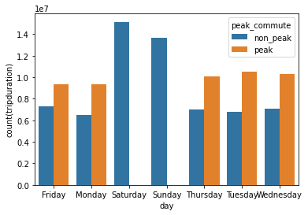

```python
sb.barplot(data = sb_df, x = 'day', y = 'count(tripduration)', hue = 'peak_commute')
```

**Trip durations:**

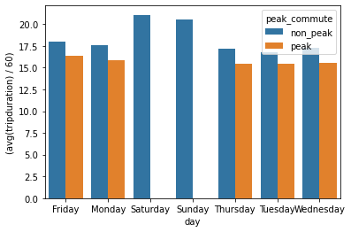

```python
sb.barplot(data = sb_df, x = 'day', y = '(avg(tripduration) / 60)', hue = 'peak_commute')
```

```python
sb_df = bike_gt2017.groupBy('weather_main', 'peak_commute')\
.agg(F.mean('tripduration')/60, F.count('tripduration'))\
.sort(['weather_main', 'peak_commute'])
```

```python
sb_df = sb_df.toPandas()
```

```python
sb_df
```

|  | weather_main | peak_commute | (avg(tripduration) / 60) | count(tripduration) |
| --- | --- | --- | --- | --- |
| 0 | Clear | non_peak | 19.604422 | 30106457 |
| 1 | Clear | peak | 15.940208 | 21424593 |
| 2 | Clouds | non_peak | 18.846084 | 19475530 |
| 3 | Clouds | peak | 15.906759 | 17570434 |
| 4 | Drizzle | non_peak | 10.576008 | 339 |
| 5 | Fog | non_peak | 14.997894 | 107269 |
| 6 | Fog | peak | 13.600072 | 70497 |
| 7 | Haze | non_peak | 19.663033 | 943980 |
| 8 | Haze | peak | 17.111334 | 578911 |
| 9 | Mist | non_peak | 16.569241 | 4450911 |
| 10 | Mist | peak | 14.116857 | 3411863 |
| 11 | Rain | non_peak | 17.921730 | 8064772 |
| 12 | Rain | peak | 15.505157 | 6291277 |
| 13 | Snow | non_peak | 12.469411 | 329375 |
| 14 | Snow | peak | 12.358570 | 334801 |
| 15 | Thunderstorm | non_peak | 37.327229 | 2468 |

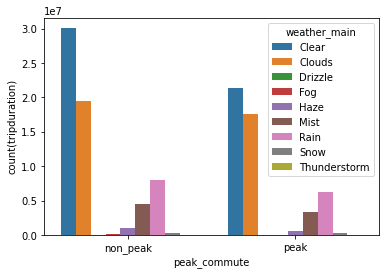

```python
sb.barplot(data = sb_df, x = 'peak_commute', y = 'count(tripduration)', hue = 'weather_main')
```

**Huge differences in trip numbers between weather types.**

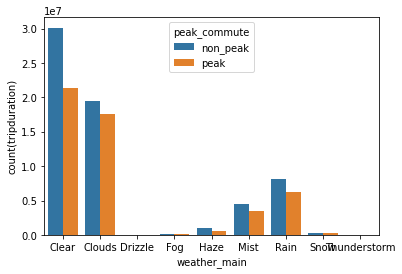

```python
sb.barplot(data = sb_df, x = 'weather_main', y = 'count(tripduration)', hue = 'peak_commute')
```

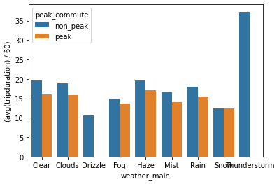

```python
sb.barplot(data = sb_df, x = 'weather_main', y = '(avg(tripduration) / 60)', hue = 'peak_commute')
```

```python
# create general precipication columns rather than rain and snow split
bike_gt2017 = bike_gt2017.withColumn('3h_precip', bike_gt2017.rain_3h + bike_gt2017.snow_3h)\
.withColumn('1h_precip', bike_gt2017.rain_1h + bike_gt2017.snow_1h)
```

*See missing data*

```python
bike_gt2017.select([F.count(when(col(c).isNull(), c)).alias(c) for c in bike_gt2017.columns]).show()
```

```
+----+----+------------+---------+--------------+----------------+--------------------+---------------------+------------+--------------+------------------+-------------------+-------+--------+---------+-------+----+----------+--------+--------+--------+--------+----------+-------+-------+-------+--…
|date|hour|tripduration|starttime|startStationId|startStationName|startStationLatitude|startStationLongitude|endStationId|endStationName|endStationLatitude|endStationLongitude| bikeid|usertype|birthyear| gender|temp|feels_like|temp_min|temp_max|pressure|humidity|wind_speed|rain_1h|rain_3h|snow_1h|sn…
+----+----+------------+---------+--------------+----------------+--------------------+---------------------+------------+--------------+------------------+-------------------+-------+--------+---------+-------+----+----------+--------+--------+--------+--------+----------+-------+-------+-------+--…
|   0|   0|           0|        0|          2771|            3035|                   0|                    0|        2771|         16945|             13973|              13973|7279098|       0|  7279098|7279098|   0|         0|       0|       0|       0|       0|         0|      0|      0|      0|  …
+----+----+------------+---------+--------------+----------------+--------------------+---------------------+------------+--------------+------------------+-------------------+-------+--------+---------+-------+----+----------+--------+--------+--------+--------+----------+-------+-------+-------+--…
```

```python
bike_gt2017.count()
```

```
113163477
```

```python
bike_gt2017.show()
```

```
+----------+----+------------+--------------------+--------------+------------------+--------------------+---------------------+------------+--------------------+------------------+-------------------+-------+----------+---------+------+------+----------+--------+--------+--------+--------+---------…
|      date|hour|tripduration|           starttime|startStationId|  startStationName|startStationLatitude|startStationLongitude|endStationId|      endStationName|endStationLatitude|endStationLongitude| bikeid|  usertype|birthyear|gender|  temp|feels_like|temp_min|temp_max|pressure|humidity|wind_spee…
+----------+----+------------+--------------------+--------------+------------------+--------------------+---------------------+------------+--------------------+------------------+-------------------+-------+----------+---------+------+------+----------+--------+--------+--------+--------+---------…
|2018-06-20|  17|         598|2018-06-20 17:44:...|          3236|W 42 St & Dyer Ave|   40.75898361206055|    -73.9937973022461|       442.0|     W 27 St & 7 Ave|40.746646881103516| -73.99391174316406|32018.0|Subscriber|     1971|   1.0|79.772|    78.116|  73.384|  73.384|    1011|      37|      1.6…
|2018-06-20|  17|         674|2018-06-20 17:52:...|          3236|W 42 St & Dyer Ave|   40.75898361206055|    -73.9937973022461|       499.0|  Broadway & W 60 St|  40.7691535949707| -73.98191833496094|31393.0|Subscriber|     1978|   1.0|79.772|    78.116|  73.384|  73.384|    1011|      37|      1.6…
|2018-06-20|  17|         296|2018-06-20 17:56:...|          3236|W 42 St & Dyer Ave|   40.75898361206055|    -73.9937973022461|      3635.0|     W 36 St & 9 Ave| 40.75462341308594| -73.99517059326172|25564.0|Subscriber|     1981|   1.0|79.772|    78.116|  73.384|  73.384|    1011|      37|      1.6…
|2018-06-20|  17|         648|2018-06-20 17:56:...|          3236|W 42 St & Dyer Ave|   40.75898361206055|    -73.9937973022461|       212.0|W 16 St & The Hig...|40.743350982666016| -74.00682067871094|33356.0|Subscriber|     1978|   1.0|79.772|    78.116|  73.384|  73.384|    1011|      37|      1.6…
|2018-06-20|  18|         114|2018-06-20 18:03:...|          3236|W 42 St & Dyer Ave|   40.75898361206055|    -73.9937973022461|      3236.0|  W 42 St & Dyer Ave| 40.75898361206055|  -73.9937973022461|16804.0|Subscriber|     1991|   1.0| 80.51|    78.638|  75.994|  75.994|    1010|      39|      2.2…
|2018-06-20|  18|        1265|2018-06-20 18:06:...|          3236|W 42 St & Dyer Ave|   40.75898361206055|    -73.9937973022461|       127.0|Barrow St & Hudso...| 40.73172378540039| -74.00674438476562|32563.0|Subscriber|     1986|   1.0| 80.51|    78.638|  75.994|  75.994|    1010|      39|      2.2…
|2018-06-20|  18|        1329|2018-06-20 18:07:...|          3236|W 42 St & Dyer Ave|   40.75898361206055|    -73.9937973022461|       151.0|Cleveland Pl & Sp...|40.722103118896484| -73.99724578857422|31492.0|  Customer|     1989|   1.0| 80.51|    78.638|  75.994|  75.994|    1010|      39|      2.2…
|2018-06-20|  18|         450|2018-06-20 18:11:...|          3236|W 42 St & Dyer Ave|   40.75898361206055|    -73.9937973022461|       490.0|     8 Ave & W 33 St| 40.75155258178711| -73.99393463134766|14878.0|Subscriber|     1991|   1.0| 80.51|    78.638|  75.994|  75.994|    1010|      39|      2.2…
|2018-06-20|  18|        1131|2018-06-20 18:23:...|          3236|W 42 St & Dyer Ave|   40.75898361206055|    -73.9937973022461|       540.0|Lexington Ave & E...| 40.74311447143555|  -73.9821548461914|16804.0|Subscriber|     1972|   2.0| 80.51|    78.638|  75.994|  75.994|    1010|      39|      2.2…
|2018-06-20|  18|         260|2018-06-20 18:39:...|          3236|W 42 St & Dyer Ave|   40.75898361206055|    -73.9937973022461|       478.0|    11 Ave & W 41 St| 40.76029968261719| -73.99884033203125|29409.0|Subscriber|     1993|   1.0| 80.51|    78.638|  75.994|  75.994|    1010|      39|      2.2…
|2018-06-20|  18|         401|2018-06-20 18:44:...|          3236|W 42 St & Dyer Ave|   40.75898361206055|    -73.9937973022461|       514.0|    12 Ave & W 40 St|  40.7608757019043| -74.00277709960938|29849.0|Subscriber|     1967|   2.0| 80.51|    78.638|  75.994|  75.994|    1010|      39|      2.2…
|2018-06-20|  18|         868|2018-06-20 18:46:...|          3236|W 42 St & Dyer Ave|   40.75898361206055|    -73.9937973022461|      3641.0|  Broadway & W 25 St| 40.74287033081055| -73.98918914794922|17242.0|Subscriber|     1987|   1.0| 80.51|    78.638|  75.994|  75.994|    1010|      39|      2.2…
|2018-06-20|  19|         208|2018-06-20 19:07:...|          3236|W 42 St & Dyer Ave|   40.75898361206055|    -73.9937973022461|       490.0|     8 Ave & W 33 St| 40.75155258178711| -73.99393463134766|32827.0|Subscriber|     1965|   1.0|81.266|    80.582|  74.107|  74.107|    1010|      42|      2.0…
```

[output cut: 9 more lines]

```python
#bike_gt2017.select(bike_gt2017.weather_main).distinct().show()
```

```python
#bike_gt2017.select(bike_gt2017.startStationId).distinct().show()
```

### We do not care about exact type of precipitation event, particularly since trip characteristics between the types are so imbalanced. Map to `precip` v. `no_precip`.

```python
precip_map = {'Thunderstorm':'precip', 'Drizzle':'precip',
 'Fog':'no_precip', 'Clear':'no_precip',
 'Mist':'precip', 'Clouds':'no_precip', 'Rain':'precip',
 'Snow':'precip', 'Haze':'no_precip'}
```

```python
bike_gt2017 = bike_gt2017.withColumn('precip', translate(precip_map)('weather_main'))
```

```python
bike_gt2017.show(5)
```

```
+----------+----+------------+--------------------+--------------+------------------+--------------------+---------------------+------------+--------------------+------------------+-------------------+-------+----------+---------+------+------+----------+--------+--------+--------+--------+---------…
|      date|hour|tripduration|           starttime|startStationId|  startStationName|startStationLatitude|startStationLongitude|endStationId|      endStationName|endStationLatitude|endStationLongitude| bikeid|  usertype|birthyear|gender|  temp|feels_like|temp_min|temp_max|pressure|humidity|wind_spee…
+----------+----+------------+--------------------+--------------+------------------+--------------------+---------------------+------------+--------------------+------------------+-------------------+-------+----------+---------+------+------+----------+--------+--------+--------+--------+---------…
|2018-06-20|  17|         598|2018-06-20 17:44:...|          3236|W 42 St & Dyer Ave|   40.75898361206055|    -73.9937973022461|       442.0|     W 27 St & 7 Ave|40.746646881103516| -73.99391174316406|32018.0|Subscriber|     1971|   1.0|79.772|    78.116|  73.384|  73.384|    1011|      37|      1.6…
|2018-06-20|  17|         674|2018-06-20 17:52:...|          3236|W 42 St & Dyer Ave|   40.75898361206055|    -73.9937973022461|       499.0|  Broadway & W 60 St|  40.7691535949707| -73.98191833496094|31393.0|Subscriber|     1978|   1.0|79.772|    78.116|  73.384|  73.384|    1011|      37|      1.6…
|2018-06-20|  17|         296|2018-06-20 17:56:...|          3236|W 42 St & Dyer Ave|   40.75898361206055|    -73.9937973022461|      3635.0|     W 36 St & 9 Ave| 40.75462341308594| -73.99517059326172|25564.0|Subscriber|     1981|   1.0|79.772|    78.116|  73.384|  73.384|    1011|      37|      1.6…
|2018-06-20|  17|         648|2018-06-20 17:56:...|          3236|W 42 St & Dyer Ave|   40.75898361206055|    -73.9937973022461|       212.0|W 16 St & The Hig...|40.743350982666016| -74.00682067871094|33356.0|Subscriber|     1978|   1.0|79.772|    78.116|  73.384|  73.384|    1011|      37|      1.6…
|2018-06-20|  18|         114|2018-06-20 18:03:...|          3236|W 42 St & Dyer Ave|   40.75898361206055|    -73.9937973022461|      3236.0|  W 42 St & Dyer Ave| 40.75898361206055|  -73.9937973022461|16804.0|Subscriber|     1991|   1.0| 80.51|    78.638|  75.994|  75.994|    1010|      39|      2.2…
+----------+----+------------+--------------------+--------------+------------------+--------------------+---------------------+------------+--------------------+------------------+-------------------+-------+----------+---------+------+------+----------+--------+--------+--------+--------+---------…
only showing top 5 rows
```

```python
bike_gt2017 = bike_gt2017.withColumn('3h_precip', bike_gt2017.rain_3h + bike_gt2017.snow_3h)\
.withColumn('1h_precip', bike_gt2017.rain_1h + bike_gt2017.snow_1h)
```

[figure not shown]

```python
sb.barplot(data = sb_df, x = 'precip', y = '(avg(tripduration) / 60)', hue = 'peak_commute')
```

```python
bike_gt2017.show(5)
```

```
+----------+----+------------+--------------------+--------------+------------------+--------------------+---------------------+------------+--------------------+------------------+-------------------+-------+----------+---------+------+------+----------+--------+--------+--------+--------+---------…
|      date|hour|tripduration|           starttime|startStationId|  startStationName|startStationLatitude|startStationLongitude|endStationId|      endStationName|endStationLatitude|endStationLongitude| bikeid|  usertype|birthyear|gender|  temp|feels_like|temp_min|temp_max|pressure|humidity|wind_spee…
+----------+----+------------+--------------------+--------------+------------------+--------------------+---------------------+------------+--------------------+------------------+-------------------+-------+----------+---------+------+------+----------+--------+--------+--------+--------+---------…
|2018-06-20|  17|         598|2018-06-20 17:44:...|          3236|W 42 St & Dyer Ave|   40.75898361206055|    -73.9937973022461|       442.0|     W 27 St & 7 Ave|40.746646881103516| -73.99391174316406|32018.0|Subscriber|     1971|   1.0|79.772|    78.116|  73.384|  73.384|    1011|      37|      1.6…
|2018-06-20|  17|         674|2018-06-20 17:52:...|          3236|W 42 St & Dyer Ave|   40.75898361206055|    -73.9937973022461|       499.0|  Broadway & W 60 St|  40.7691535949707| -73.98191833496094|31393.0|Subscriber|     1978|   1.0|79.772|    78.116|  73.384|  73.384|    1011|      37|      1.6…
|2018-06-20|  17|         296|2018-06-20 17:56:...|          3236|W 42 St & Dyer Ave|   40.75898361206055|    -73.9937973022461|      3635.0|     W 36 St & 9 Ave| 40.75462341308594| -73.99517059326172|25564.0|Subscriber|     1981|   1.0|79.772|    78.116|  73.384|  73.384|    1011|      37|      1.6…
|2018-06-20|  17|         648|2018-06-20 17:56:...|          3236|W 42 St & Dyer Ave|   40.75898361206055|    -73.9937973022461|       212.0|W 16 St & The Hig...|40.743350982666016| -74.00682067871094|33356.0|Subscriber|     1978|   1.0|79.772|    78.116|  73.384|  73.384|    1011|      37|      1.6…
|2018-06-20|  18|         114|2018-06-20 18:03:...|          3236|W 42 St & Dyer Ave|   40.75898361206055|    -73.9937973022461|      3236.0|  W 42 St & Dyer Ave| 40.75898361206055|  -73.9937973022461|16804.0|Subscriber|     1991|   1.0| 80.51|    78.638|  75.994|  75.994|    1010|      39|      2.2…
+----------+----+------------+--------------------+--------------+------------------+--------------------+---------------------+------------+--------------------+------------------+-------------------+-------+----------+---------+------+------+----------+--------+--------+--------+--------+---------…
only showing top 5 rows
```

### Get unique stations and their lats and longs

- We need to use these to help map and join to other data

```python
stat_df = bike_gt2017.select('startStationId', 'startStationName', 'startStationLatitude', 'startStationLongitude')\
.distinct()
```

```python
stat_df = stat_df.toPandas()
```

```python
stat_df.to_csv('\stations.csv')
```

### Write joined weather and Citi Bike data to parquet files

```python
bike_gt2017.write.parquet("/project/ds5559/Summer2021_TeamBike/gt2017_bikeweather.parquet")
```